# Data 607: Assignment 2B

Author

Ellie Wilser

## Approach

For this assignment, I plan to go through the planned out code chucks below which matches the assignment tasks. Before starting to code, I plan to read through the provided PDF and get a refresh on binary classification. I have worked with these model’s before, but the PDF will be useful. I don’t think I will have too many difficulties with this assignment, but I want to challenge myself to use Git in terminal and make a graph using ggplot 2.

## Code

### Loading Data and Libraries

```r
library(readr)
library(dplyr)
library(tidyverse)
```

```r
url <- "https://raw.githubusercontent.com/EllieWilser/Data_607/refs/heads/main/Assignment_2/penguin_predictions.csv"

penguin_pred <- read_csv(
  file = url,
  show_col_types = FALSE,
  progress = FALSE
)


penguin_pred
```

| .pred_female | .pred_class | sex |
| --- | --- | --- |
| 9.921746e-01 | female | female |
| 9.542394e-01 | female | female |
| 9.847350e-01 | female | female |
| 1.870206e-01 | male | female |
| 9.947012e-01 | female | female |
| 9.999891e-01 | female | female |
| 9.593662e-01 | female | female |
| 9.998613e-01 | female | female |
| 9.999749e-01 | female | female |
| 3.394058e-01 | male | female |

[output cut: 83 more lines]

### Data Exploration

In this section, I performed basic data exploration using dplyr and creating a summary table. The summary table gives a quick overview of how the classification model performed, and contain counts of type I and II errors.

```r
summary_table <- penguin_pred %>%
  group_by(sex,.pred_class) %>%
  summarise(
    count_sex = n(),
    avg_female_pred_prob = mean(.pred_female),
    .groups = "drop"
  )

summary_table
```

| sex | .pred_class | count_sex | avg_female_pred_prob |
| --- | --- | --- | --- |
| female | female | 36 | 0.98973716 |
| female | male | 3 | 0.20281666 |
| male | female | 3 | 0.83929844 |
| male | male | 51 | 0.03355092 |

### Graph

I created a graph that shows where the model is making errors in terms of Predicted Probability of Female. From the graph, you can see that the model is making errors when the probability is closer to .5.

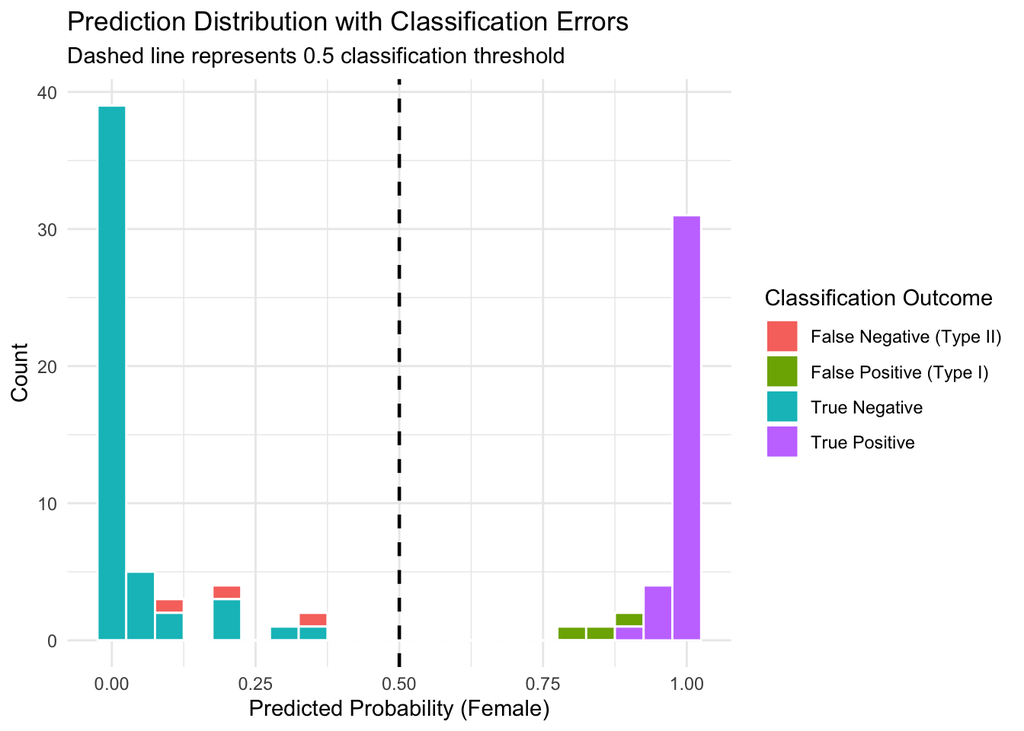

```r
penguin_eval <- penguin_pred %>%
  mutate(
    outcome = case_when(
      sex == "female" & .pred_class == "female" ~ "True Positive",
      sex == "male" & .pred_class == "male"     ~ "True Negative",
      sex == "male" & .pred_class == "female"   ~ "False Positive (Type I)",
      sex == "female" & .pred_class == "male"   ~ "False Negative (Type II)"
    )
  )

ggplot(penguin_eval, aes(x=.pred_female, fill = outcome)) +
  geom_histogram(binwidth = 0.05, color = "white", position = "stack") +
  geom_vline(xintercept = 0.5, linetype = "dashed", color = "black", linewidth = 0.8) +
  theme_minimal() +
  labs(
    title = "Prediction Distribution with Classification Errors",
    subtitle = "Dashed line represents 0.5 classification threshold",
    x = "Predicted Probability (Female)",
    y = "Count",
    fill = "Classification Outcome"
  )
```

### Null Error Rate

In this section, I calculated the null error rate for the penguin sample and created a graph showing the distribution of penguin sex. The null error rate tells you the error rate of taking the best guess, so this means the model created should have an error rate that is significantly less.

```r
null_error_rate <- penguin_pred %>%
  count(sex) %>%
  mutate(proportion = n / sum(n)) %>%
  summarise(null_error_rate = 1 - max(proportion))

null_error_rate
```

| null_error_rate |
| --- |
| 0.4193548 |

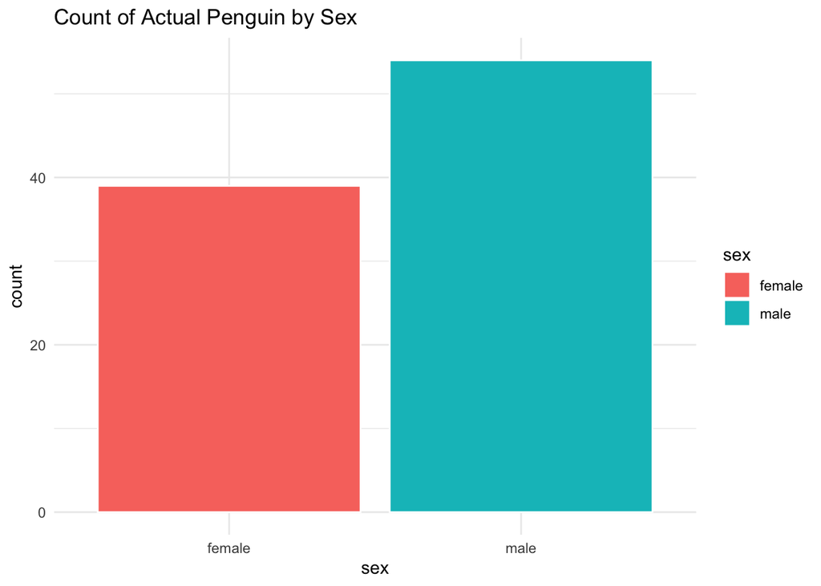

```r
ggplot(penguin_pred, aes(x=sex,fill=sex))+
  geom_bar(color="white") +
  theme_minimal()+
  labs(
    title = "Count of Actual Penguin by Sex"
  )
```

### Confusion Matrices at Multiple Thresholds

```r
library(yardstick)
#Turns sex into a factor
penguin_eval <- penguin_pred %>%
  mutate(sex = factor(sex, levels = c("female", "male")))

print("--- Threshold: 0.2 ---")
```

```
[1] "--- Threshold: 0.2 ---"
```

```r
matrix_1 <- penguin_eval %>%
  mutate(pred = factor(ifelse(.pred_female >= 0.2, "female", "male"), levels = c("female", "male"))) %>%
  conf_mat(truth = sex, estimate = pred)
matrix_1
```

```
          Truth
Prediction female male
    female     37    6
    male        2   48
```

```r
print("--- Threshold: 0.5 ---")
```

```
[1] "--- Threshold: 0.5 ---"
```

```r
matrix_2 <- penguin_eval %>%
  mutate(pred = factor(ifelse(.pred_female >= 0.5, "female", "male"), levels = c("female", "male"))) %>%
  conf_mat(truth = sex, estimate = pred)
matrix_2
```

```
          Truth
Prediction female male
    female     36    3
    male        3   51
```

```r
print("--- Threshold: 0.8 ---")
```

```
[1] "--- Threshold: 0.8 ---"
```

```r
matrix_3 <- penguin_eval %>%
  mutate(pred = factor(ifelse(.pred_female >= 0.8, "female", "male"), levels = c("female", "male"))) %>%
  conf_mat(truth = sex, estimate = pred)
matrix_3
```

```
          Truth
Prediction female male
    female     36    2
    male        3   52
```

### Performance Metrics

For the performance metrics, I used the yardstick package again. I created a function to extract the metrics from my matrices above, and then ran the function on each matrix.

```r
extract_metrics <- function(matrix, threshold_label) {
  summary(matrix) %>%
    filter(.metric %in% c("accuracy", "precision", "recall", "f_meas")) %>%
    select(.metric, .estimate) %>%
    mutate(Threshold = threshold_label)
}

metrics_table <- bind_rows(
  extract_metrics(matrix_1, "0.2"),
  extract_metrics(matrix_2, "0.5"),
  extract_metrics(matrix_3, "0.8")
) %>%
  pivot_wider(names_from = .metric, values_from = .estimate) %>%
  select(Threshold, accuracy, precision, recall, f_meas)

print(metrics_table)
```

```
# A tibble: 3 × 5
  Threshold accuracy precision recall f_meas
  <chr>        <dbl>     <dbl>  <dbl>  <dbl>
1 0.2          0.914     0.860  0.949  0.902
2 0.5          0.935     0.923  0.923  0.923
3 0.8          0.946     0.947  0.923  0.935
```

For reference this is what the yardstick package “summary” function creates

```r
summary(matrix_1)
```

| .metric | .estimator | .estimate |
| --- | --- | --- |
| accuracy | binary | 0.9139785 |
| kap | binary | 0.8258427 |
| sens | binary | 0.9487179 |
| spec | binary | 0.8888889 |
| ppv | binary | 0.8604651 |
| npv | binary | 0.9600000 |
| mcc | binary | 0.8289917 |
| j_index | binary | 0.8376068 |
| bal_accuracy | binary | 0.9188034 |
| detection_prevalence | binary | 0.4623656 |

[output cut: 3 more lines]

### **Threshold Use Cases**

Picking the threshold for the model is useful when trying to minimize either Type I or Type II errors. A higher threshold minimizes Type I error and lower threshold minimizes Type II. The trade off is when minimizing one type of error, the rate of the other error type increases. This can be seen in the graph below:

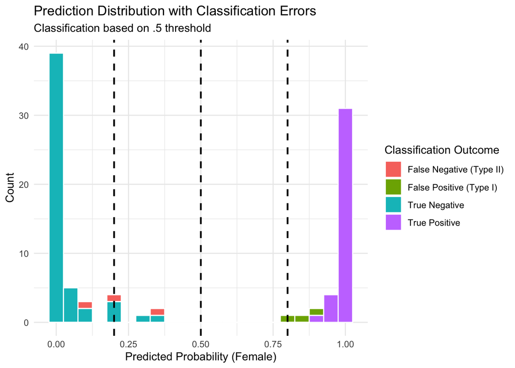

```r
penguin_eval <- penguin_pred %>%
  mutate(
    outcome = case_when(
      sex == "female" & .pred_class == "female" ~ "True Positive",
      sex == "male" & .pred_class == "male"     ~ "True Negative",
      sex == "male" & .pred_class == "female"   ~ "False Positive (Type I)",
      sex == "female" & .pred_class == "male"   ~ "False Negative (Type II)"
    )
  )

ggplot(penguin_eval, aes(x=.pred_female, fill = outcome)) +
  geom_histogram(binwidth = 0.05, color = "white", position = "stack") +
  geom_vline(xintercept = 0.5, linetype = "dashed", color = "black", linewidth = 0.8) +
  geom_vline(xintercept = 0.8, linetype = "dashed", color = "black", linewidth = 0.8) +
  geom_vline(xintercept = 0.2, linetype = "dashed", color = "black", linewidth = 0.8) +
  theme_minimal() +
  labs(
    title = "Prediction Distribution with Classification Errors",
    subtitle = "Classification based on .5 threshold",
    x = "Predicted Probability (Female)",
    y = "Count",
    fill = "Classification Outcome"
  )
```

## Conclusion

I felt this assignment gave me a great exposure to binary classification, as well as performance metrics. Exploring the data set with ggplot2 gave me a deeper understanding of Type I and II errors. For the future, I think more exposure to working with the yardstick package will help my understanding of using the package.